# UFC Fight Predictor

**By: Joseph Hong**

[figure not shown]

Israel Adesanya vs Anderson Silva ([source](https://www.mmafighting.com/2021/2/14/22282317/ufc-259-poster-released?utm_campaign=mmafighting&utm_content=chorus&utm_medium=social&utm_source=twitter))

## Introduction

Throughout history, humans have competed against each other in activities to see who comes out on top. Combat sports have been a popular means of measuring who is the stronger person usually involving one-on-one combat, attracting many spectators and athletes. From medieval tournaments to martial arts competitions, combat sports have been a staple in the entertainment industry.

One of the more recent combat sports that has gained a lot of traction is mixed martial arts (MMA). Originally referred to as Vale Tudo, MMA is a full-contact combat sport that employs various techniques and skills from martial arts around the world in order to be used in competition (more detail can be found [here](https://www.ufc.com/intro-to-mma)). While many MMA organizations have been created, The Ultimate Fight Championship ([UFC](https://www.ufc.com/)) is the world's largest MMA promotion and boasts some of the highest-level fighters in the sport on its roster. The UFC is split into 12 weight divisions (eight men's and four women's) and each fight consists of three five-minute rounds or five rounds for title matches.

Before matches even begin, there is always a bunch of discussion on who will actually win the fight. Oftentimes, people will compare the stats between fighters to see which fighter has the advantage. In this tutorial we are going to investigate how the differences in fighter stats can determine whether or not a fighter will win before a match starts. We'll look deeper into how a fighter's measurements, match statistics, and fight history play a role in the outcome of a fight.

### Required Libraries and Tools

The following libraries/tools will be used throughout the project, you can read more about in them through their documentation in the links below:

- [numpy](https://numpy.org/doc/stable/): for performing mathematical operations on arrays
- [pandas](https://pandas.pydata.org/pandas-docs/stable/): for data manipulation and analysis
- [matplotlib](https://matplotlib.org/stable/index.html): for data visualization
- [seaborn](https://seaborn.pydata.org/api.html): for data visualization based on `matplotlib`
- [statsmodel](https://www.statsmodels.org/stable/api.html): for estimating and conducting statistical models and tests,
- [sklearn](https://scikit-learn.org/stable/modules/classes.html): for regressions and modelling

```python
# importing required libraries
import numpy as np
import pandas as pd
import matplotlib.pyplot as plt
import seaborn as sns
import statsmodels.api as sm
from sklearn.linear_model import LogisticRegression
from sklearn.model_selection import train_test_split
from sklearn.metrics import classification_report, roc_auc_score, roc_curve
```

## Part 1: Data Collection

The first step in this project is to collect data. The [UFC Stats](http://ufcstats.com/) webpage contains information about all the fighters and matches. We would usually have to scrape the data from the web page itself but fortunately for us, there is already a publicly available dataset from [Kaggle](https://www.kaggle.com/datasets/rajeevw/ufcdata) that contains the UFC fight historical data from 1993 to 2021. You can also access the data set [here](https://github.com/hongjos/hongjos.github.io/tree/main/UFC/data). We use the `pandas` library to convert the data into a dataframe so we can do some analysis on the data later.

```python
# read data from csv file and convert to dataframe
df = pd.read_csv('ufc-data.csv')
df.shape
```

```
(6012, 144)
```

Fighting techniques in MMA are split into two categories:

1. striking (standing)
2. grappling (on the ground)

The original dataset has 144 variables and a lot of the them pertain to the fighter's striking and grappling statistics of the fighters. More variables could potentially give us bettery accuracy but we don't want our data to be too complex so we will only take the stats that summarize the two, which are significant strikes and knockdowns for striking, and takedowns and submissions for grappling.

```python
# extract important columns from dataframe
fields = np.array([0,1,5,8,9,10,11,12,13,14,58,59,60,62,63,71,72,73,74,75,76,77,78,79,80,81,125,126,127,129,130,138,139,140,141,142,143])
df = df.iloc[:,fields]

# set display option to view columns
pd.set_option('display.max_columns', 70)

df.head(3)
```

|  | R_fighter | B_fighter | Winner | B_avg_KD | B_avg_opp_KD | B_avg_SIG_STR_pct | B_avg_opp_SIG_STR_pct | B_avg_TD_pct | B_avg_opp_TD_pct | B_avg_SUB_ATT | B_total_title_bouts | B_current_win_streak | B_current_lose_streak | B_wins | B_losses | B_Stance | B_Height_cms | B_Reach_cms | B_Weight_lbs | R_avg_KD | R_avg_opp_KD | R_avg_SIG_STR_pct | R_avg_opp_SIG_STR_pct | R_avg_TD_pct | R_avg_opp_TD_pct | R_avg_SUB_ATT | R_total_title_bouts | R_current_win_streak | R_current_lose_streak | … |
| --- | --- | --- | --- | --- | --- | --- | --- | --- | --- | --- | --- | --- | --- | --- | --- | --- | --- | --- | --- | --- | --- | --- | --- | --- | --- | --- | --- | --- | --- | --- |
| 0 | Adrian Yanez | Gustavo Lopez | Red | 0.0 | 0.0 | 0.42 | 0.495 | 0.33 | 0.36 | 0.5 | 0 | 0 | 1 | 1 | 1 | Orthodox | 165.10 | 170.18 | 135.0 | 1.000000 | 0.0000 | 0.500000 | 0.460000 | 0.00000 | 0.00000 | 0.00 | 0 | 1 | 0 | … |
| 1 | Trevin Giles | Roman Dolidze | Red | 0.5 | 0.0 | 0.66 | 0.305 | 0.30 | 0.50 | 1.5 | 0 | 2 | 0 | 2 | 0 | Orthodox | 187.96 | 193.04 | 205.0 | 1.031250 | 0.0625 | 0.576875 | 0.381250 | 0.40625 | 0.11625 | 0.25 | 0 | 2 | 0 | … |
| 2 | Tai Tuivasa | Harry Hunsucker | Red | NaN | NaN | NaN | NaN | NaN | NaN | NaN | 0 | 0 | 0 | 0 | 0 | Orthodox | 187.96 | 190.50 | 241.0 | 0.546875 | 0.1875 | 0.538906 | 0.598594 | 0.00000 | 0.31250 | 0.00 | 0 | 3 | 0 | … |

What we're left with is data from all the different UFC fights before the match has happened, with the target `Winner` variable that is the only column that tells you what happened.

Each row contains information about the two fighters, the one in red tape, and the other in blue tape.

```python
# filter columns of the dataframe by Red or Blue fighter
def filter_df(color):
    return [col for col in df if col.startswith(color)]

df[filter_df('R')].head(3)
```

|  | R_fighter | R_avg_KD | R_avg_opp_KD | R_avg_SIG_STR_pct | R_avg_opp_SIG_STR_pct | R_avg_TD_pct | R_avg_opp_TD_pct | R_avg_SUB_ATT | R_total_title_bouts | R_current_win_streak | R_current_lose_streak | R_wins | R_losses | R_Stance | R_Height_cms | R_Reach_cms | R_Weight_lbs | R_age |
| --- | --- | --- | --- | --- | --- | --- | --- | --- | --- | --- | --- | --- | --- | --- | --- | --- | --- | --- |
| 0 | Adrian Yanez | 1.000000 | 0.0000 | 0.500000 | 0.460000 | 0.00000 | 0.00000 | 0.00 | 0 | 1 | 0 | 1 | 0 | Orthodox | 170.18 | 177.80 | 135.0 | 27.0 |
| 1 | Trevin Giles | 1.031250 | 0.0625 | 0.576875 | 0.381250 | 0.40625 | 0.11625 | 0.25 | 0 | 2 | 0 | 4 | 2 | Orthodox | 182.88 | 187.96 | 185.0 | 28.0 |
| 2 | Tai Tuivasa | 0.546875 | 0.1875 | 0.538906 | 0.598594 | 0.00000 | 0.31250 | 0.00 | 0 | 3 | 0 | 4 | 3 | Southpaw | 187.96 | 190.50 | 264.0 | 28.0 |

```python
df[filter_df('B')].head(3)
```

|  | B_fighter | B_avg_KD | B_avg_opp_KD | B_avg_SIG_STR_pct | B_avg_opp_SIG_STR_pct | B_avg_TD_pct | B_avg_opp_TD_pct | B_avg_SUB_ATT | B_total_title_bouts | B_current_win_streak | B_current_lose_streak | B_wins | B_losses | B_Stance | B_Height_cms | B_Reach_cms | B_Weight_lbs | B_age |
| --- | --- | --- | --- | --- | --- | --- | --- | --- | --- | --- | --- | --- | --- | --- | --- | --- | --- | --- |
| 0 | Gustavo Lopez | 0.0 | 0.0 | 0.42 | 0.495 | 0.33 | 0.36 | 0.5 | 0 | 0 | 1 | 1 | 1 | Orthodox | 165.10 | 170.18 | 135.0 | 31.0 |
| 1 | Roman Dolidze | 0.5 | 0.0 | 0.66 | 0.305 | 0.30 | 0.50 | 1.5 | 0 | 2 | 0 | 2 | 0 | Orthodox | 187.96 | 193.04 | 205.0 | 32.0 |
| 2 | Harry Hunsucker | NaN | NaN | NaN | NaN | NaN | NaN | NaN | 0 | 0 | 0 | 0 | 0 | Orthodox | 187.96 | 190.50 | 241.0 | 32.0 |

For the information on the fighters:

- the `R_` and `B_` prefixes signify info on the Red and Blue fighter
- the `_opp_` tag indicates the defense of the fighter or the damage taken by the fighter (done by the opponent)

Each fighter contains information on their match statistics which are:

- `avg_KD`: the average number of knockdowns per fight
- `avg_SIG_STR_pct`: significant striking accuracy
- `avg_TD_pct`: takedown accuracy
- `avg_SUB_ATT`: average submission attempts

The information about the fighters include:

- the total number of title bouts
- their current win or lose streak before the match happens
- the total number of wins and losses
- the fighting stance
- their height (cm), reach (cm), weight (lbs) and age

## Part 2: Data Preprocessing

### Dealing With Missing Data

Oftentimes, many datasets will contain missing data, and in our case, there are fighters which are missing some match statistics and measurements. There are three ways to deal with the missing data

1. ignoring them
2. imputation or finding reasonable guesses
3. removing the data itself

Simply ignoring missing values isn’t going to do much so we’ll use the latter two ways.

Some fighters are missing their age, which often means that they only participated in one match, making them insignificant, so we'll just drop them from the dataframe. We'll end up losing some observations, but we only want to look at fighters with enough data.

```python
# drop fighters without any ages
df = df.dropna(axis=0, subset=['R_age','B_age'], thresh=2)
```

Since a fighters match statistics is based on previous matches, a lot of fighters will have missing values if the fight was considered to be their first fight. We can’t just put in 0 for the values, because a 0% significant strike accuracy means the fighter didn’t deal any notable blows. Getting rid of this would mean removing a lot of entries in our dataset so to treat this, we will fill in the fight statistics with the average of all fighters who only had one match.

Since the rows of the original dataset have information on both red and blue fighters, we will have to combine the two to take the mean values of the stats of the fighters.

```python
# prefix for red and blue fighter
pre = ['R_', 'B_']

# get total matches for each fighter
for i in pre:
    df[i+'total_matches'] = df[i+'wins'] + df[i+'losses']

# ditionary store red and blue fighters
fighters = dict.fromkeys(['R_', 'B_'], None)

# grab fighter stats for red and blue fighters
fighters['R_']= df[filter_df('R_')[1:19]]
fighters['B_'] = df[filter_df('B_')[1:19]]

# combine red and blue fighters into one dataframe
def combine_fighters(f):
    # rename columns (get rid of prefix) for red and blue fighters
    for i in pre:
        for c in f[i].columns:
            f[i] = f[i].rename(columns={c:c[2:]})

    return pd.concat([f['R_'], f['B_']], axis=0)

fighters = combine_fighters(fighters)

# fill in missing fight stats for fighters with 0 matches
for i in pre:
    for c in fighters.columns[0:7]:
        # get mean value of fight stat from fighters with one match
        val = fighters[fighters['total_matches'] == 1][c].mean()

        # fill missing value of stat if fighter has no matches
        df[i+c] = df.apply(lambda r: val if (r[i+'total_matches'] == 0 and pd.isna(r[i+c])) else r[i+c], axis=1)

# check columns with missing values
df.loc[:, df.isna().any()].isna().sum()
```

```
B_Stance         43
B_Height_cms      2
B_Reach_cms     707
R_Stance         22
R_Reach_cms     268
dtype: int64
```

A good portion of the data on the fighter's reach is missing. One method is just to remove the columns altogether, but in MMA (and especially boxing, which is used in MMA), a fighter's reach is [important](https://evolve-mma.com/blog/does-a-height-and-reach-advantage-necessarily-make-you-a-better-mixed-martial-artist/) in a fight as a longer reach can make it easier to land strikes on the opponent.

Because of the way humans are, a person’s reach is often determined by their height, meaning that taller people will generally have a long reach. To fill in the missing values, we’ll find fighters with similar heights and take the median value of their reach.

```python
# get unique fighters
reach_mask = fighters.groupby('Height_cms')['Reach_cms'].median()
reach_mask
```

```
Height_cms
152.40    152.40
154.94    157.48
157.48    160.02
160.02    162.56
162.56    165.10
165.10    167.64
167.64    170.18
170.18    175.26
172.72    177.80
175.26    180.34
177.80    182.88
180.34    185.42
182.88    187.96
185.42    190.50
187.96    193.04
190.50    195.58
193.04    200.66
195.58    200.66
198.12    200.66
200.66    203.20
203.20    203.20
208.28       NaN
210.82    213.36
Name: Reach_cms, dtype: float64
```

As seen, a UFC fighter's reach is generally slightly higher than their height. There isn't any data on the reach for fighters at 208.28cm so we'll just fill the `reach_mask` value with the same height plus the average increase from height to reach. Although these reaches aren't the exact values, so our data is not completely accurate, it still gives us a relatively good estimate.

```python
# fill in missing reach_mask average difference from reach and height + original value
avg_inc = (reach_mask.sum() - sum(list(reach_mask.index)) + 202.28) / len(reach_mask)
reach_mask[208.28] = 208.28 + avg_inc

# fill in missing reach values
for i in pre:
    df[i+'Reach_cms'] = df[i+'Reach_cms'].fillna(df[i+'Height_cms'].map(reach_mask))
```

There are some fighters with missing stances so we’ll just replace them with the most [common](https://en.wikipedia.org/wiki/Orthodox_stance) stance used in MMA, which is the Orthodox stance. There are also two missing height values in which we can manually fill in with a quick google search.

```python
# fill in empty stances with orthodox
df[['R_Stance','B_Stance']] = df[['R_Stance','B_Stance']].fillna('Orthodox')


# fill in missing height values for Edward Faaloloto
df.at[4270, 'B_Height_cms'] = 175.26
df.at[4388, 'B_Height_cms'] = 175.26

print(f'missing values: {df.loc[:, df.isna().any()].isna().sum()}')
```

```
missing values: Series([], dtype: float64)
```

Now we have no missing values so we can continue on to the next steps.

### More Data Cleaning

We can represent the current win and loss streak columns into a single streak column as there will never be a nonzero value in both columns (so a negative value will represent a losing streak).

```python
# combine current win and loss streak into one and drop them
for i in pre:
    df[i+'current_streak'] = df[i+'current_win_streak'] - df[i+'current_lose_streak']
    df = df.drop([i+'current_win_streak', i+'current_lose_streak'], axis=1)
```

Some of the column names are capitalized and some aren't so we'll rename and reorganize the columns so the data frame looks neater.

```python
# function to captialize first letters separated by commas
def upper_case(s):
    lst = s.split('_')
    lst = [x if x in ['KD', 'TD'] else x.capitalize() for x in lst]
    return '_'.join(lst)

# renaming columns
for i in pre:
    df = df.rename(columns={i+'avg_opp_KD': i+'avg_KD_taken', i+'avg_SIG_STR_pct': i+'SIG_STR_Acc',
                            i+'avg_opp_SIG_STR_pct': i+'SIG_STR_Def', i+'avg_TD_pct': i+'TD_Acc',
                            i+'avg_opp_TD_pct': i+'TD_Def', i+'Height_cms': i+'Height',
                            i+'Reach_cms': i+'Reach', i+'Weight_lbs': i+'Weight'})

for c in df.columns:
    df = df.rename(columns={c:upper_case(c)})


# reordering columns
df = pd.concat([df.iloc[:,0:3], df[filter_df('R_')].iloc[:,1:], df[filter_df('B_')].iloc[:,1:]], axis=1)
```

`Sig_Str_Def` and `TD_Def` are represented as the percent of hits taken by the fighter so `Def` is a bit misleading, so we will represent the columns as the percent of hits that did not land.

```python
# change percent of hits taken to percent that did not land
for i in pre:
    df[i+'Sig_Str_Def'] = abs(1.0-df[i+'Sig_Str_Def'])
    df[i+'TD_Def'] = abs(1.0-df[i+'TD_Def'])

# change to percent values
percent = ['Sig_Str_Acc', 'Sig_Str_Def', 'TD_Acc', 'TD_Def']

for x in percent:
    for i in pre:
        df[i+x] = 100 * df[i+x]
```

### Difference of Stats

As stated before, we are interested in comparing the stats of fighters to see who will come out on top. So for all the non-categorical columns for the red and blue fighters, we'll make a column that shows the difference of stats between the two fighters (`R` - `B`)

```python
# filter numeric columns
numeric = df[filter_df('R')].select_dtypes(exclude=['object'])

# add columns for difference between red and blue stats
for i in numeric.columns:
    n = i[2:]
    df[n+'_Diff'] = df['R_' + n]-df['B_' + n]

df.head()
```

|  | R_Fighter | B_Fighter | Winner | R_Avg_KD | R_Avg_KD_Taken | R_Sig_Str_Acc | R_Sig_Str_Def | R_TD_Acc | R_TD_Def | R_Avg_Sub_Att | R_Total_Title_Bouts | R_Wins | R_Losses | R_Stance | R_Height | R_Reach | R_Weight | R_Age | R_Total_Matches | R_Current_Streak | B_Avg_KD | B_Avg_KD_Taken | B_Sig_Str_Acc | B_Sig_Str_Def | B_TD_Acc | B_TD_Def | B_Avg_Sub_Att | B_Total_Title_Bouts | B_Wins | … |
| --- | --- | --- | --- | --- | --- | --- | --- | --- | --- | --- | --- | --- | --- | --- | --- | --- | --- | --- | --- | --- | --- | --- | --- | --- | --- | --- | --- | --- | --- | --- |
| 0 | Adrian Yanez | Gustavo Lopez | Red | 1.000000 | 0.000000 | 50.000000 | 54.000000 | 0.000000 | 100.000000 | 0.000000 | 0 | 1 | 0 | Orthodox | 170.18 | 177.80 | 135.0 | 27.0 | 1 | 1 | 0.000000 | 0.000000 | 42.000000 | 50.500000 | 33.000000 | 64.000000 | 0.50000 | 0 | 1 | … |
| 1 | Trevin Giles | Roman Dolidze | Red | 1.031250 | 0.062500 | 57.687500 | 61.875000 | 40.625000 | 88.375000 | 0.250000 | 0 | 4 | 2 | Orthodox | 182.88 | 187.96 | 185.0 | 28.0 | 6 | 2 | 0.500000 | 0.000000 | 66.000000 | 69.500000 | 30.000000 | 50.000000 | 1.50000 | 0 | 2 | … |
| 2 | Tai Tuivasa | Harry Hunsucker | Red | 0.546875 | 0.187500 | 53.890625 | 40.140625 | 0.000000 | 68.750000 | 0.000000 | 0 | 4 | 3 | Southpaw | 187.96 | 190.50 | 264.0 | 28.0 | 7 | 3 | 0.201318 | 0.177352 | 45.295986 | 55.287597 | 29.294188 | 70.209107 | 0.52846 | 0 | 0 | … |
| 3 | Cheyanne Buys | Montserrat Conejo | Blue | 0.201318 | 0.177352 | 45.295986 | 55.287597 | 29.294188 | 70.209107 | 0.528460 | 0 | 0 | 0 | Switch | 160.02 | 160.02 | 115.0 | 25.0 | 0 | 0 | 0.201318 | 0.177352 | 45.295986 | 55.287597 | 29.294188 | 70.209107 | 0.52846 | 0 | 0 | … |
| 4 | Marion Reneau | Macy Chiasson | Blue | 0.000000 | 0.000977 | 40.307617 | 44.503906 | 51.171875 | 37.125000 | 0.231445 | 0 | 5 | 6 | Orthodox | 167.64 | 172.72 | 135.0 | 43.0 | 11 | 2 | 0.125000 | 0.000000 | 53.562500 | 42.125000 | 18.500000 | 83.375000 | 0.12500 | 1 | 4 | … |

## Part 3: Exploratory Data Analysis

Now that we're done with the data preprocessing, let's move on to analyzing the data and exploring how the outcome of fights is affected by the different fighter variables.

```python
# define coordinate space for graphing
coord = [[0,0], [0,1], [1,0], [1,1]]

# create color palette for graphing
colors = sns.color_palette('Set2', 10)
```

We will first separate the stats from the losers and winners so we can compare them later on.

```python
# define winners and losers
winners = dict.fromkeys(['R_', 'B_'], None)
losers = dict.fromkeys(['R_', 'B_'], None)

# combine fighter data from winners
winners['R_'] = df[df['Winner']=='Red'][filter_df('R_')].iloc[:,1:]
winners['B_'] = df[df['Winner']=='Blue'][filter_df('B_')].iloc[:,1:]
winners = combine_fighters(winners)

# combine fighter data from losers
losers['R_'] = df[df['Winner']=='Red'][filter_df('B_')].iloc[:,1:]
losers['B_'] = df[df['Winner']=='Blue'][filter_df('R_')].iloc[:,1:]
losers = combine_fighters(losers)

# combine both winners and losers
total = pd.concat([winners, losers], axis=0)
```

### Fighter Measurements

We'll now look at how the measurements (of the height, reach, weight, and age) differs between the winners and the losers. Let's look at the distribution of the measurements between all fighters first.

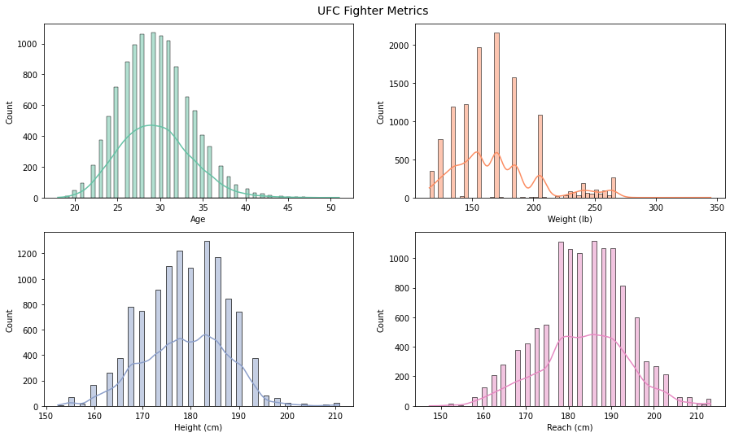

```python
m_labels = ['Age', 'Weight', 'Height', 'Reach']
m_names = ['Age', 'Weight (lb)', 'Height (cm)', 'Reach (cm)']

# plot distribution of measurements for all fighters
f, ax = plt.subplots(2, 2, figsize=(15,8))

plt.suptitle('UFC Fighter Metrics', fontsize=14)
plt.subplots_adjust(top=0.94)

# plot each metric
for i, m in enumerate(m_labels):
    x = coord[i][0]
    y = coord[i][1]
    sns.histplot(x=total[m], kde=True, color=colors[i], ax=ax[x,y])
    ax[x,y].set_xlabel(m_names[i])

plt.show()
```

The majority of fighters are between the ages of 25-35. This isn't surprising as many careers in MMA don't last very long because fighters take a lot of damage during matches, so as a result, we don't see many fighters in their late 30s or above. Athletes also need to accumulate enough skill and get enough experience in order to compete so there aren't many young fighters in their early 20s.

Height and reach are similar and have around the same range of values (with reach being a bit more than height), which also isn't surprising as they are based off of each other. UFC has separate weight divisions, so there aren't many distinct values, we can see here that the most popular weight division is between 150 and 200 lbs. Now let's look at the differences between winners and losers.

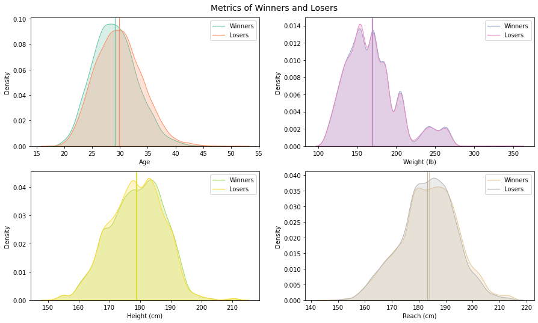

```python
# plot distribution of winners and losers
f, ax = plt.subplots(2, 2, figsize=(15,8))

plt.suptitle('Metrics of Winners and Losers', fontsize=14)
plt.subplots_adjust(top=0.94)

# function to plot distribution of winners and losers of some variable
def plot_win_lose(i, stat, label):
    x = coord[i][0]
    y = coord[i][1]

    # plot winner and mean value
    sns.kdeplot(winners[stat], color=colors[2*i], shade=True, ax=ax[x,y])
    ax[x,y].axvline(x=winners[stat].mean(), color=colors[2*i], linewidth=1.2)
    # plot loser and mean value
    sns.kdeplot(losers[stat], color=colors[2*i+1], shade=True, ax=ax[x,y])
    ax[x,y].axvline(x=losers[stat].mean(), color=colors[2*i+1], linewidth=1.2)

    ax[x,y].set_xlabel(label[i])
    ax[x,y].legend(['Winners','Losers'])

# plot each metric
for i, m in enumerate(m_labels):
    plot_win_lose(i, m, m_names)

plt.show()
```

It's surprising to see that the winners and losers don't seem to have much difference in height. Although winners did have a bit more taller people, the mean difference is almost zero. The distribution of the weights between winners and losers were almost identical, which makes sense because the UFC is split into different weight divisions so there shouldn't be too much of a difference in weight between fighters.

The measurements of fighters isn't everything in determining whether or not they will win so let's take a look into the actual fight statistics.

### Striking Statistics

Striking takes place in the feet, which includes punches, kicks, elbows, and knees. We'll now visualize the distribution of the differences of striking stats between the winners and losers, looking at the offense and defense of the fighter's significant strikes and knockdowns.

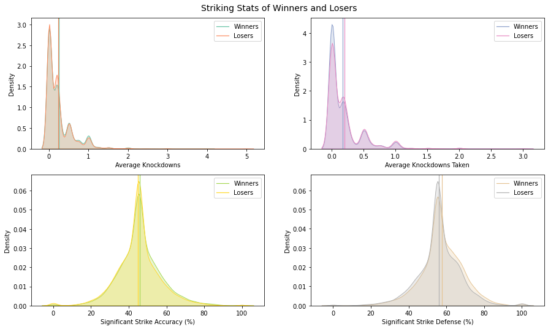

```python
s_labels = ['Avg_KD', 'Avg_KD_Taken', 'Sig_Str_Acc', 'Sig_Str_Def']
s_names = ['Average Knockdowns', 'Average Knockdowns Taken', 'Significant Strike Accuracy (%)', 'Significant Strike Defense (%)']

# plot distribution of winners and losers
f, ax = plt.subplots(2, 2, figsize=(15,8))

plt.suptitle('Striking Stats of Winners and Losers', fontsize=14)
plt.subplots_adjust(top=0.94)

# plot each striking stat
for i, s in enumerate(s_labels):
    plot_win_lose(i, s, s_names)

plt.show()
```

It seems that for a fighter's striking stat, having a higher significant strike defense will give you a better chance in winning. The winners tended to have a slightly higher significant strike accuracy and defense than the losers, although the difference in accuracies were much smaller.

Knockdown stats were more similar for both winners and losers. There wasn't much of a difference for average number of knockdowns dealt, this is a bit surprising because knockdowns usually have a significant effect on the scoring decision done by the judges. However, winners did have a little bit less average number of knockdowns taken.

### Grappling Statistics

Grappling takes place on the ground and focuses on controlling and submitting opponents using proper technique and leverage. We'll now look at the distribution of the differences of grappling stats between the winners and losers, focusing on submission attempts and the offense and defense of the fighter's takedown stats.

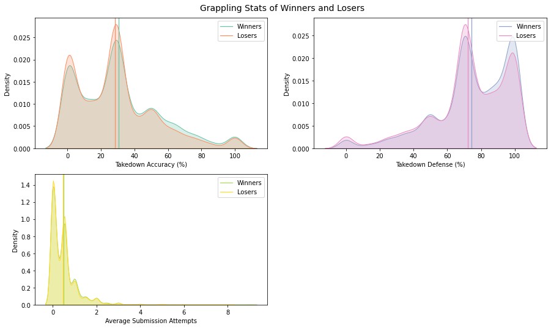

```python
g_labels = ['TD_Acc', 'TD_Def', 'Avg_Sub_Att']
g_names = ['Takedown Accuracy (%)', 'Takedown Defense (%)', 'Average Submission Attempts']

# plot distribution of winners and losers
f, ax = plt.subplots(2, 2, figsize=(15,8))

plt.suptitle('Grappling Stats of Winners and Losers', fontsize=14)
plt.subplots_adjust(top=0.94)

# plot each grappling stat
for i, g in enumerate(g_labels):
    plot_win_lose(i, g, g_names)

# delete extra axes
f.delaxes(ax[1][1])

plt.show()
```

Takedowns seem to have more of an impact on the match decision. From the graphs, it can be seen that the winners had a greater takedown accuracy and defense when compared to the losers. The difference is more pronounced when compared to the differences of statistics before, making takedowns one of the more important variables to look at. Submission attempts were pretty much identical between winners and losers, so it doesn't look like it has much of an effect on the match outcome.

### Which Stance is Best?

Like how there isn't a "best" martial arts, there isn't really a universal best stance. However, it would be interesting to see which stance gets the most wins. We will first look at whihc stances are commonly used.

```python
# get stance value counts
total['Stance'].value_counts().rename_axis('Stance').reset_index(name='counts')
```

|  | Stance | counts |
| --- | --- | --- |
| 0 | Orthodox | 8708 |
| 1 | Southpaw | 2290 |
| 2 | Switch | 399 |
| 3 | Open Stance | 22 |
| 4 | Sideways | 1 |

Orthodox stance dominates, which is then followed by southpaw, as these are the two main stances for right and left handed people.

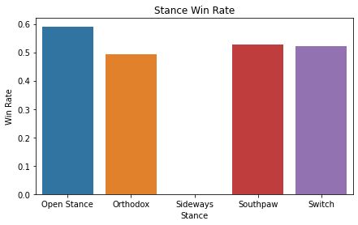

```python
# plot stance win rate
plt.figure(figsize=(7,4))
stance_win = winners['Stance'].value_counts() / total['Stance'].value_counts()
sns.barplot(x=stance_win.index, y=stance_win.values)
plt.title('Stance Win Rate')
plt.xlabel('Stance')
plt.ylabel('Win Rate')
plt.show()
```

Besides the 0 for 1 match for the fighter using the sideways stance, orthodox has the lowest win rate, which is then followed by switch, and then southpaw. Open stance boasts the highest win rate, reaching almost 60% but there were only 22 times where it appears. We would need more data on fighters using open stance to get a better understanding of the win rate, but from the data here, it doesn't look like there is a truly better stance.

### Match History

Lets look at how the experience of a fighter's history plays a role in the match decision.

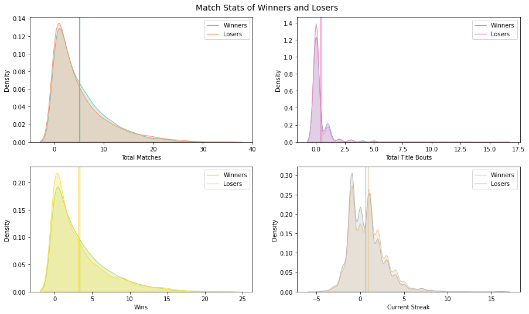

```python
w_labels = ['Total_Matches', 'Total_Title_Bouts', 'Wins', 'Current_Streak']
w_names = ['Total Matches', 'Total Title Bouts', 'Wins', 'Current Streak']

# plot distribution of winners and losers
f, ax = plt.subplots(2, 2, figsize=(15,8))

plt.suptitle('Match Stats of Winners and Losers', fontsize=14)
plt.subplots_adjust(top=0.94)

# plot each stat
for i, w in enumerate(w_labels):
    plot_win_lose(i, w, w_names)

plt.show()
```

It doesn't seem like there is a big difference between the total matches and wins of winners and losers. MMA matchups need to be fair so fighters will be put with others on similar skill levels or else the sport wouldn't be as interesting to watch. For title bouts, it looks like winners had slightly more title bouts when compared to losers. The most visible difference was the current streak of fighter as winners tended to have a higher current win streak, which intuitively makes sense.

## Part 4: Hypothesis Testing and Machine Learning

### Which Factors are Important?

Based on our data analysis, I think that the most important variables to look at when comparing the stats between fighters are the `Age`, `Reach`, `Avg_KD_Taken`, `Sig_Str_Acc`, `Sig_Str_Def`,`TD_Acc`, `TD_Def`, `Total_Title_Bouts`, and `Current_Streak`.

We'll test our hypothesis that there is a relationship between the difference of fighter stats of these variables and match outcome, against the null hypothesis that there is no relationship. To test this, we will fit a binary logistic regression, which is essentially used the find the probability of an event occuring, with the assumption that our independent variables are independent of each other. You can find more information about logistic regressions [here](https://www.ibm.com/topics/logistic-regression). Since our target variable is whether or not the fighter wins or loses, we will need to get rid of the draws (there aren't many anyways so our data set won't be affected by too much).

We first need to transform all our categorical variables into numeric values, this means that we need to represent the `Winner` outcome into 1s and 0s instead of red and blue.

```python
# remove draws and change Winner to 1 and 0
df = df[df['Winner'] != 'Draw']
df['Winner'] = df['Winner'].replace(['Red', 'Blue'], [1,0])
```

We'll need to define our features and target in order to fit a logistic regression using `statsmodel`. Oftentimes, with `statsmodel`, we should add a constant column to the features, you can read more on why we do this [here](https://stats.stackexchange.com/questions/440242/statsmodels-logistic-regression-adding-intercept). For this project, we'll define our significance level to be 0.05 which is the most common significance level.

```python
# define features
# features = list(df.iloc[:,-16:].columns)
features = ['Age_Diff', 'Reach_Diff', 'Avg_KD_Taken_Diff', 'Sig_Str_Acc_Diff', 'Sig_Str_Def_Diff',
            'TD_Acc_Diff', 'TD_Def_Diff', 'Total_Title_Bouts_Diff', 'Current_Streak_Diff']
X = df[features]

# define target
y = df['Winner']

# fit logistic regression, print summary
log_reg = sm.Logit(y, sm.add_constant(X)).fit()
log_reg.summary()
```

```
Optimization terminated successfully.
         Current function value: 0.615128
         Iterations 5
```

Logit Regression Results

| Dep. Variable: | Winner | No. Observations: | 5710 |
| --- | --- | --- | --- |
| Model: | Logit | Df Residuals: | 5700 |
| Method: | MLE | Df Model: | 9 |
| Date: | Sun, 15 May 2022 | Pseudo R-squ.: | 0.03681 |
| Time: | 23:28:04 | Log-Likelihood: | -3512.4 |
| converged: | True | LL-Null: | -3646.6 |
| Covariance Type: | nonrobust | LLR p-value: | 1.242e-52 |

|  | coef | std err | z | P>\|z\| | [0.025 | 0.975] |
| --- | --- | --- | --- | --- | --- | --- |
| const | 0.7026 | 0.030 | 23.709 | 0.000 | 0.645 | 0.761 |
| Age_Diff | -0.0649 | 0.006 | -11.202 | 0.000 | -0.076 | -0.054 |
| Reach_Diff | 0.0105 | 0.004 | 2.956 | 0.003 | 0.004 | 0.017 |
| Avg_KD_Taken_Diff | -0.2418 | 0.074 | -3.266 | 0.001 | -0.387 | -0.097 |
| Sig_Str_Acc_Diff | 0.0063 | 0.002 | 3.338 | 0.001 | 0.003 | 0.010 |
| Sig_Str_Def_Diff | 0.0097 | 0.002 | 5.041 | 0.000 | 0.006 | 0.013 |
| TD_Acc_Diff | 0.0022 | 0.001 | 2.447 | 0.014 | 0.000 | 0.004 |
| TD_Def_Diff | 0.0025 | 0.001 | 2.608 | 0.009 | 0.001 | 0.004 |
| Total_Title_Bouts_Diff | 0.0165 | 0.017 | 0.950 | 0.342 | -0.018 | 0.050 |
| Current_Streak_Diff | 0.0275 | 0.012 | 2.379 | 0.017 | 0.005 | 0.050 |

When we look at the pseudo R-squared value (a substitute for [R-squared](https://www.geeksforgeeks.org/ml-r-squared-in-regression-analysis/) in least squares linear regression), we see that this number extremely low, only having a value of 0.03681. So, while most of the variables may be significant, they don't explain much of the variability in the dependent variable. This [post](https://statisticsbyjim.com/regression/low-r-squared-regression/), goes into more detail about models that have significant variables but low R-squared value.

### Predicting Match Outcomes

Eventhough our logisitic regression fit had a low pseudo R-squared value, lets try to predict match outcomes anyways. Since `Total_Title_Bouts` wasn't a signficiant varialbe, we'l get rid of that from the feautres. To train our model we'll have to split our data into a test and training set.

**Why not [Decision Trees](https://www.ibm.com/docs/en/cognos-analytics/11.1.0?topic=analytics-decision-tree)?**

A common way to classify something is to use a decision tree model or random forests (which uses many decision trees). I decided to stick with a logistic regression model for classification because it is more simple and faster and all of the significant variables were numeric anyways. If we had a lot of categorical variables, decision trees/random forests might be a better choice.

```python
# remove total title bouts
X = X.drop('Total_Title_Bouts_Diff', 1)

# split into training and test set
X_train, X_test, y_train, y_test = train_test_split(X, y, test_size=0.25, random_state=0)

# create regressor
lr = LogisticRegression()

# train the model
lr.fit(X_train, y_train)

# predicitng test results
y_pred = lr.predict(X_test)
```

Let's see how well our model did.

```python
print(classification_report(y_test, y_pred))
```

```
              precision    recall  f1-score   support

           0       0.55      0.09      0.15       484
           1       0.67      0.96      0.79       944

    accuracy                           0.67      1428
   macro avg       0.61      0.52      0.47      1428
weighted avg       0.63      0.67      0.57      1428
```

As you can see, our model had an accuracy of 67%. It isn't the best but it would still be better than randomly guessing which fighter will win. We can plot a [ROC](https://developers.google.com/machine-learning/crash-course/classification/roc-and-auc) curve which shows the performance of the model at all classification thresholds.

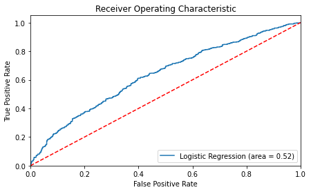

```python
# code taken from https://towardsdatascience.com/building-a-logistic-regression-in-python-step-by-step-becd4d56c9c8

# compute area under ROC
roc = roc_auc_score(y_test, lr.predict(X_test))

# compute ROC
fpr, tpr, thresholds = roc_curve(y_test, lr.predict_proba(X_test)[:,1])

plt.figure(figsize=(7,4))

# plot ROC
plt.plot(fpr, tpr, label='Logistic Regression (area = %0.2f)' % roc)
# plot random classifier
plt.plot([0, 1], [0, 1],'r--')

plt.xlim([0.0, 1.0])
plt.ylim([0.0, 1.05])
plt.xlabel('False Positive Rate')
plt.ylabel('True Positive Rate')
plt.title('Receiver Operating Characteristic')
plt.legend(loc="lower right")
plt.show()
```

The dotted red line represents the ROC curve of a purely random classifier. The ROC shows the model's false positive rate against the true positive and we want our models to be as far away from the line as possible toward the upper left corner. While our model may still outperform random guessing, there is a lot of room for improvement. Comparing the stats of a fighter before the fight has happened isn't everything when looking at the match outcome.

## Conclusion

After exploring the effects of how the differences in stats of fighters relate to the fight outcome, it appears that just looking at the differences between the fighter stats won't tell you everything. However, from our data analysis, we have found that the differences between the fighters age and average knockdowns taken has the greatest effect on the match outcome, when we are just looking at the numbers themselves.

Since MMA allows various martial arts techniques, there are a lot of different aspects to look at when comparing fighters. While we did only select a couple of features that represented the striking and grappling stats of fighters, we could improve this model at the expense of being more complicated, by looking at more features such as the number of head, body and leg strikes. We could also look at how these differences differentiate between the different UFC weight divisions, but for the purpose of this analysis, I have decided to stick with UFC matches overall, as it is still a relatively new sport and there isn't a huge amount of data about it out there.

We could go a different route to see how different fighting techniques, like Muay Thai or Brazilian Jiu-Jitsu, fare against each other by analyzing the important stats related to the techniques and the win rates, or we could focus on a sport with more restrictive rules, such as boxing.

Thank you for reading this project, and I hope that you have learned a bit more about data science and MMA.